# Attrition Prediction

Shelloren

January 16, 2020

# Background

As I state in my first version of this topic, unwanted attritions are **expensive** not just in figure of money but mentally for all employee in the office. So to preventing this is some improvement that we all can invested in.

Here the list of libraries that i used :

```r
library(tidyverse)
library(tidymodels)
library(ranger)
library(ggplot2)
library(lime)
```

## Dataset

```r
# import dataset
data_hr <- read_csv("data_input/WA_Fn-UseC_-HR-Employee-Attrition.csv")
data_hr
```

| Age | Attrition | BusinessTravel | DailyRate | Department | DistanceFromHome | Education | EducationField | EmployeeCount | EmployeeNumber | EnvironmentSatisfaction | Gender | HourlyRate | JobInvolvement | JobLevel | JobRole | JobSatisfaction | MaritalStatus | MonthlyIncome | MonthlyRate | NumCompaniesWorked | Over18 | OverTime | PercentSalaryHike | PerformanceRating | RelationshipSatisfaction | StandardHours | StockOptionLevel | TotalWorkingYears | TrainingTimesLastYear | … |
| --- | --- | --- | --- | --- | --- | --- | --- | --- | --- | --- | --- | --- | --- | --- | --- | --- | --- | --- | --- | --- | --- | --- | --- | --- | --- | --- | --- | --- | --- | --- |
| 41 | Yes | Travel_Rarely | 1102 | Sales | 1 | 2 | Life Sciences | 1 | 1 | 2 | Female | 94 | 3 | 2 | Sales Executive | 4 | Single | 5993 | 19479 | 8 | Y | Yes | 11 | 3 | 1 | 80 | 0 | 8 | 0 | … |
| 49 | No | Travel_Frequently | 279 | Research & Development | 8 | 1 | Life Sciences | 1 | 2 | 3 | Male | 61 | 2 | 2 | Research Scientist | 2 | Married | 5130 | 24907 | 1 | Y | No | 23 | 4 | 4 | 80 | 1 | 10 | 3 | … |
| 37 | Yes | Travel_Rarely | 1373 | Research & Development | 2 | 2 | Other | 1 | 4 | 4 | Male | 92 | 2 | 1 | Laboratory Technician | 3 | Single | 2090 | 2396 | 6 | Y | Yes | 15 | 3 | 2 | 80 | 0 | 7 | 3 | … |
| 33 | No | Travel_Frequently | 1392 | Research & Development | 3 | 4 | Life Sciences | 1 | 5 | 4 | Female | 56 | 3 | 1 | Research Scientist | 3 | Married | 2909 | 23159 | 1 | Y | Yes | 11 | 3 | 3 | 80 | 0 | 8 | 3 | … |
| 27 | No | Travel_Rarely | 591 | Research & Development | 2 | 1 | Medical | 1 | 7 | 1 | Male | 40 | 3 | 1 | Laboratory Technician | 2 | Married | 3468 | 16632 | 9 | Y | No | 12 | 3 | 4 | 80 | 1 | 6 | 3 | … |
| 32 | No | Travel_Frequently | 1005 | Research & Development | 2 | 2 | Life Sciences | 1 | 8 | 4 | Male | 79 | 3 | 1 | Laboratory Technician | 4 | Single | 3068 | 11864 | 0 | Y | No | 13 | 3 | 3 | 80 | 0 | 8 | 2 | … |
| 59 | No | Travel_Rarely | 1324 | Research & Development | 3 | 3 | Medical | 1 | 10 | 3 | Female | 81 | 4 | 1 | Laboratory Technician | 1 | Married | 2670 | 9964 | 4 | Y | Yes | 20 | 4 | 1 | 80 | 3 | 12 | 3 | … |
| 30 | No | Travel_Rarely | 1358 | Research & Development | 24 | 1 | Life Sciences | 1 | 11 | 4 | Male | 67 | 3 | 1 | Laboratory Technician | 3 | Divorced | 2693 | 13335 | 1 | Y | No | 22 | 4 | 2 | 80 | 1 | 1 | 2 | … |
| 38 | No | Travel_Frequently | 216 | Research & Development | 23 | 3 | Life Sciences | 1 | 12 | 4 | Male | 44 | 2 | 3 | Manufacturing Director | 3 | Single | 9526 | 8787 | 0 | Y | No | 21 | 4 | 2 | 80 | 0 | 10 | 2 | … |
| 36 | No | Travel_Rarely | 1299 | Research & Development | 27 | 3 | Medical | 1 | 13 | 3 | Male | 94 | 3 | 2 | Healthcare Representative | 3 | Married | 5237 | 16577 | 6 | Y | No | 13 | 3 | 2 | 80 | 2 | 17 | 3 | … |

[output cut: 1460 more lines]

In this project I try to predict employee attrition we’ll still use a data set provide by [IBM - Watson Analytics Community Sample Data](https://www.ibm.com/communities/analytics/watson-analytics-blog/hr-employee-attrition/).

- `Attrition`: Yes or No Parameter whether the employee commit attrition.
- `BusinessTravel`: One of factor of `Non-Travel`, `Travel_Frequently` and `Travel_Rarely`
- `Education`: Ranged from 1 `Below College`, 2 `College`, 3 `Bachelor`, 4 `Master` and 5 `Doctor`
- `EnvironmentSatisfaction`:Rating from employee range from; 1 `Low`, 2 `Medium`, 3 `High` and 4 `Very High`. This appraisal were included in few parameters such as;`JobInvolvement`,`RelationshipSatisfaction`, `PerformanceRating`, `JobSatisfaction` and `WorkLifeBalance`.

```r
skimr::skim(data_hr)
```

Data summary

| Name | data_hr |
| --- | --- |
| Number of rows | 1470 |
| Number of columns | 35 |
| _______________________ |  |
| Column type frequency: |  |
| character | 9 |
| numeric | 26 |
| ________________________ |  |
| Group variables | None |

**Variable type: character**

| skim_variable | n_missing | complete_rate | min | max | empty | n_unique | whitespace |
| --- | --- | --- | --- | --- | --- | --- | --- |
| Attrition | 0 | 1 | 2 | 3 | 0 | 2 | 0 |
| BusinessTravel | 0 | 1 | 10 | 17 | 0 | 3 | 0 |
| Department | 0 | 1 | 5 | 22 | 0 | 3 | 0 |
| EducationField | 0 | 1 | 5 | 16 | 0 | 6 | 0 |
| Gender | 0 | 1 | 4 | 6 | 0 | 2 | 0 |
| JobRole | 0 | 1 | 7 | 25 | 0 | 9 | 0 |
| MaritalStatus | 0 | 1 | 6 | 8 | 0 | 3 | 0 |
| Over18 | 0 | 1 | 1 | 1 | 0 | 1 | 0 |
| OverTime | 0 | 1 | 2 | 3 | 0 | 2 | 0 |

**Variable type: numeric**

| skim_variable | n_missing | complete_rate | mean | sd | p0 | p25 | p50 | p75 | p100 | hist |
| --- | --- | --- | --- | --- | --- | --- | --- | --- | --- | --- |
| Age | 0 | 1 | 36.92 | 9.14 | 18 | 30.00 | 36.0 | 43.00 | 60 | ▂▇▇▃▂ |
| DailyRate | 0 | 1 | 802.49 | 403.51 | 102 | 465.00 | 802.0 | 1157.00 | 1499 | ▇▇▇▇▇ |
| DistanceFromHome | 0 | 1 | 9.19 | 8.11 | 1 | 2.00 | 7.0 | 14.00 | 29 | ▇▅▂▂▂ |
| Education | 0 | 1 | 2.91 | 1.02 | 1 | 2.00 | 3.0 | 4.00 | 5 | ▂▃▇▆▁ |
| EmployeeCount | 0 | 1 | 1.00 | 0.00 | 1 | 1.00 | 1.0 | 1.00 | 1 | ▁▁▇▁▁ |
| EmployeeNumber | 0 | 1 | 1024.87 | 602.02 | 1 | 491.25 | 1020.5 | 1555.75 | 2068 | ▇▇▇▇▇ |
| EnvironmentSatisfaction | 0 | 1 | 2.72 | 1.09 | 1 | 2.00 | 3.0 | 4.00 | 4 | ▅▅▁▇▇ |
| HourlyRate | 0 | 1 | 65.89 | 20.33 | 30 | 48.00 | 66.0 | 83.75 | 100 | ▇▇▇▇▇ |
| JobInvolvement | 0 | 1 | 2.73 | 0.71 | 1 | 2.00 | 3.0 | 3.00 | 4 | ▁▃▁▇▁ |
| JobLevel | 0 | 1 | 2.06 | 1.11 | 1 | 1.00 | 2.0 | 3.00 | 5 | ▇▇▃▂▁ |
| JobSatisfaction | 0 | 1 | 2.73 | 1.10 | 1 | 2.00 | 3.0 | 4.00 | 4 | ▅▅▁▇▇ |
| MonthlyIncome | 0 | 1 | 6502.93 | 4707.96 | 1009 | 2911.00 | 4919.0 | 8379.00 | 19999 | ▇▅▂▁▂ |
| MonthlyRate | 0 | 1 | 14313.10 | 7117.79 | 2094 | 8047.00 | 14235.5 | 20461.50 | 26999 | ▇▇▇▇▇ |
| NumCompaniesWorked | 0 | 1 | 2.69 | 2.50 | 0 | 1.00 | 2.0 | 4.00 | 9 | ▇▃▂▂▁ |
| PercentSalaryHike | 0 | 1 | 15.21 | 3.66 | 11 | 12.00 | 14.0 | 18.00 | 25 | ▇▅▃▂▁ |
| PerformanceRating | 0 | 1 | 3.15 | 0.36 | 3 | 3.00 | 3.0 | 3.00 | 4 | ▇▁▁▁▂ |
| RelationshipSatisfaction | 0 | 1 | 2.71 | 1.08 | 1 | 2.00 | 3.0 | 4.00 | 4 | ▅▅▁▇▇ |
| StandardHours | 0 | 1 | 80.00 | 0.00 | 80 | 80.00 | 80.0 | 80.00 | 80 | ▁▁▇▁▁ |
| StockOptionLevel | 0 | 1 | 0.79 | 0.85 | 0 | 0.00 | 1.0 | 1.00 | 3 | ▇▇▁▂▁ |
| TotalWorkingYears | 0 | 1 | 11.28 | 7.78 | 0 | 6.00 | 10.0 | 15.00 | 40 | ▇▇▂▁▁ |
| TrainingTimesLastYear | 0 | 1 | 2.80 | 1.29 | 0 | 2.00 | 3.0 | 3.00 | 6 | ▂▇▇▂▃ |
| WorkLifeBalance | 0 | 1 | 2.76 | 0.71 | 1 | 2.00 | 3.0 | 3.00 | 4 | ▁▃▁▇▂ |
| YearsAtCompany | 0 | 1 | 7.01 | 6.13 | 0 | 3.00 | 5.0 | 9.00 | 40 | ▇▂▁▁▁ |
| YearsInCurrentRole | 0 | 1 | 4.23 | 3.62 | 0 | 2.00 | 3.0 | 7.00 | 18 | ▇▃▂▁▁ |
| YearsSinceLastPromotion | 0 | 1 | 2.19 | 3.22 | 0 | 0.00 | 1.0 | 3.00 | 15 | ▇▁▁▁▁ |
| YearsWithCurrManager | 0 | 1 | 4.12 | 3.57 | 0 | 2.00 | 3.0 | 7.00 | 17 | ▇▂▅▁▁ |

From skims report we ensure there’s no missing value and there’s few variables that can be removed because *NearZeroVariance* or simply it won’t be use in machine learning letter in time.

# Data Preprocess/Wrangling

### Cross-Validation

We’ll do simple cross-validation with help of *rsample package*, with 75% proportion.

```r
# set seed
set.seed(1)

# create initial split
splitted <- initial_split(data_hr, prop = 0.75, strata = "Attrition")
```

### Defining Preprocess

Making recipes for the data, juice the training data and bake the testing data.

```r
# define preprocess recipe from train dataset
rec <- recipe(Attrition ~ ., data = training(splitted)) %>%
  step_rm(EmployeeCount, EmployeeNumber) %>%
  step_nzv(all_predictors()) %>%
  step_string2factor(all_nominal(), -Attrition) %>%
  step_string2factor(Attrition, levels = c("Yes", "No")) %>%
  step_downsample(Attrition, ratio = 1/1, seed = 1) %>%
  prep(strings_as_factors = FALSE)

# get train and test dataset
data_train <- juice(rec)
data_test <- bake(rec, testing(splitted))

# quick check
data_train
```

| Age | BusinessTravel | DailyRate | Department | DistanceFromHome | Education | EducationField | EnvironmentSatisfaction | Gender | HourlyRate | JobInvolvement | JobLevel | JobRole | JobSatisfaction | MaritalStatus | MonthlyIncome | MonthlyRate | NumCompaniesWorked | OverTime | PercentSalaryHike | PerformanceRating | RelationshipSatisfaction | StockOptionLevel | TotalWorkingYears | TrainingTimesLastYear | WorkLifeBalance | YearsAtCompany | YearsInCurrentRole | YearsSinceLastPromotion | YearsWithCurrManager | … |
| --- | --- | --- | --- | --- | --- | --- | --- | --- | --- | --- | --- | --- | --- | --- | --- | --- | --- | --- | --- | --- | --- | --- | --- | --- | --- | --- | --- | --- | --- | --- |
| 41 | Travel_Rarely | 1102 | Sales | 1 | 2 | Life Sciences | 2 | Female | 94 | 3 | 2 | Sales Executive | 4 | Single | 5993 | 19479 | 8 | Yes | 11 | 3 | 1 | 0 | 8 | 0 | 1 | 6 | 4 | 0 | 5 | … |
| 37 | Travel_Rarely | 1373 | Research & Development | 2 | 2 | Other | 4 | Male | 92 | 2 | 1 | Laboratory Technician | 3 | Single | 2090 | 2396 | 6 | Yes | 15 | 3 | 2 | 0 | 7 | 3 | 3 | 0 | 0 | 0 | 0 | … |
| 28 | Travel_Rarely | 103 | Research & Development | 24 | 3 | Life Sciences | 3 | Male | 50 | 2 | 1 | Laboratory Technician | 3 | Single | 2028 | 12947 | 5 | Yes | 14 | 3 | 2 | 0 | 6 | 4 | 3 | 4 | 2 | 0 | 3 | … |
| 36 | Travel_Rarely | 1218 | Sales | 9 | 4 | Life Sciences | 3 | Male | 82 | 2 | 1 | Sales Representative | 1 | Single | 3407 | 6986 | 7 | No | 23 | 4 | 2 | 0 | 10 | 4 | 3 | 5 | 3 | 0 | 3 | … |
| 34 | Travel_Rarely | 699 | Research & Development | 6 | 1 | Medical | 2 | Male | 83 | 3 | 1 | Research Scientist | 1 | Single | 2960 | 17102 | 2 | No | 11 | 3 | 3 | 0 | 8 | 2 | 3 | 4 | 2 | 1 | 3 | … |
| 32 | Travel_Frequently | 1125 | Research & Development | 16 | 1 | Life Sciences | 2 | Female | 72 | 1 | 1 | Research Scientist | 1 | Single | 3919 | 4681 | 1 | Yes | 22 | 4 | 2 | 0 | 10 | 5 | 3 | 10 | 2 | 6 | 7 | … |
| 39 | Travel_Rarely | 895 | Sales | 5 | 3 | Technical Degree | 4 | Male | 56 | 3 | 2 | Sales Representative | 4 | Married | 2086 | 3335 | 3 | No | 14 | 3 | 3 | 1 | 19 | 6 | 4 | 1 | 0 | 0 | 0 | … |
| 24 | Travel_Rarely | 813 | Research & Development | 1 | 3 | Medical | 2 | Male | 61 | 3 | 1 | Research Scientist | 4 | Married | 2293 | 3020 | 2 | Yes | 16 | 3 | 1 | 1 | 6 | 2 | 2 | 2 | 0 | 2 | 0 | … |
| 50 | Travel_Rarely | 869 | Sales | 3 | 2 | Marketing | 1 | Male | 86 | 2 | 1 | Sales Representative | 3 | Married | 2683 | 3810 | 1 | Yes | 14 | 3 | 3 | 0 | 3 | 2 | 3 | 3 | 2 | 0 | 2 | … |
| 26 | Travel_Rarely | 1357 | Research & Development | 25 | 3 | Life Sciences | 1 | Male | 48 | 1 | 1 | Laboratory Technician | 3 | Single | 2293 | 10558 | 1 | No | 12 | 3 | 3 | 0 | 1 | 2 | 2 | 1 | 0 | 0 | 1 | … |

[output cut: 346 more lines]

# Modeling

I will using ranger to do the random forest classification.

### Model Specifications

```r
# define model specification
model_spec <- rand_forest(
  mode = "classification",
  mtry = 29,
  trees = 500,
  min_n = 15
)

# define model engine
model_spec <- set_engine(
  object = model_spec,
  engine = "ranger",
  seed = 100,
  num.threads = parallel::detectCores() / 2,
  importance = "impurity"
)

# quick check
model_spec
```

```
#> Random Forest Model Specification (classification)
#>
#> Main Arguments:
#>   mtry = 29
#>   trees = 500
#>   min_n = 15
#>
#> Engine-Specific Arguments:
#>   seed = 100
#>   num.threads = parallel::detectCores()/2
#>   importance = impurity
#>
#> Computational engine: ranger
```

### Model Fitting

```r
# fit the model
model <- fit_xy(
  object = model_spec,
  x = select(data_train, -Attrition),
  y = select(data_train, Attrition)
)

# quick check
model
```

```
#> parsnip model object
#>
#> Fit in:  257msRanger result
#>
#> Call:
#>  ranger::ranger(formula = formula, data = data, mtry = ~29, num.trees = ~500,      min.node.size = ~15, seed = ~100, num.threads = ~parallel::detectCores()/2,      importance = ~"impurity", verbose = FALSE, probability = TRUE)
#>
#> Type:                             Probability estimation
#> Number of trees:                  500
#> Sample size:                      356
#> Number of independent variables:  30
#> Mtry:                             29
#> Target node size:                 15
#> Variable importance mode:         impurity
#> Splitrule:                        gini
#> OOB prediction error (Brier s.):  0.2134123
```

### Variable Importance

[figure not shown]

```r
# get variable importance
var_imp <- tidy(model$fit$variable.importance)

# tidying
var_imp <- var_imp %>%
  head(10) %>%
  rename(variable = names, importance = x) %>%
  mutate(variable = reorder(variable, importance))

# variable importance plot
ggplot(var_imp, aes(x = variable, y = importance)) +
  geom_col(fill = aes(importance)) +
  coord_flip() +
  labs(title = "Variables Importance (Top 10)", x = NULL, y = NULL, fill = NULL) +
  scale_y_continuous(expand = expand_scale(mult = c(0, 0.1))) +
  theme_minimal()
```

# Model Evaluation

## Predict on Test Dataset

```r
# predict on test
pred_test <- select(data_test, Attrition) %>%
  bind_cols(predict(model, select(data_test, -Attrition))) %>%
  bind_cols(predict(model, select(data_test, -Attrition), type = "prob"))

# quick check
head(pred_test, 3)
```

| Attrition | .pred_class | .pred_Yes | .pred_No |
| --- | --- | --- | --- |
| No | Yes | 0.6891087 | 0.3108913 |
| No | Yes | 0.6459823 | 0.3540177 |
| No | No | 0.2735887 | 0.7264113 |

## Confusion Matrix

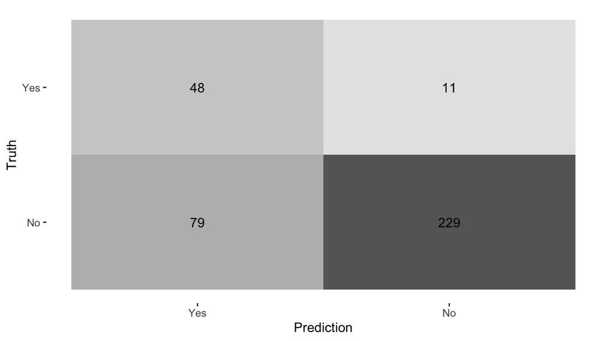

```r
# confusion matrix
pred_test %>%
  conf_mat(Attrition, .pred_class) %>%
  autoplot(type = "heatmap")
```

```r
# metrics summary
pred_test %>%
  summarise(
    accuracy = accuracy_vec(Attrition, .pred_class),
    sensitivity = sens_vec(Attrition, .pred_class),
    specificity = spec_vec(Attrition, .pred_class),
    precision = precision_vec(Attrition, .pred_class)
  )
```

| accuracy | sensitivity | specificity | precision |
| --- | --- | --- | --- |
| 0.7547684 | 0.8135593 | 0.7435065 | 0.3779528 |

# Model Explanation

We’ll use Lime

```r
set.seed(1)
explainer <- lime(x = data_train %>% select(-Attrition),
                  model = model)

explanation <- explain(x = data_test %>% select(-Attrition) %>% slice(1:4),
                       labels = "Yes",
                       explainer = explainer,
                       n_features = 5)
```

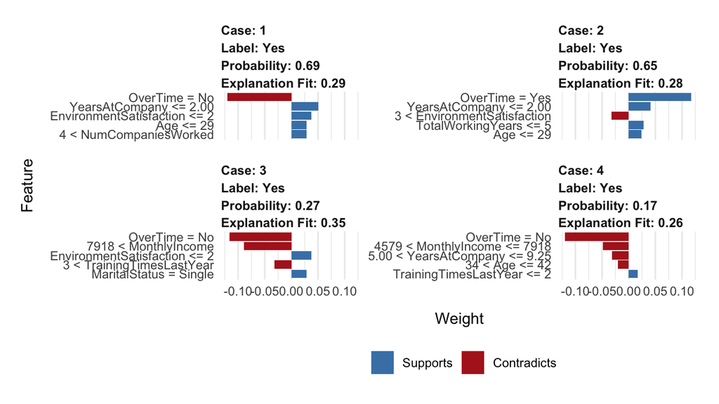

```r
plot_features(explanation)
```